# HW2

(10pts) Use the iris dataset and the SVM code shown in the first class. Define two new features using the original four features and then calculate the accuracy score of classification. The SVM classifier must use the new features and none of the original features for classification.

```python
from sklearn import datasets
iris = datasets.load_iris()
```

```python
iris.feature_names
```

```
['sepal length (cm)',
 'sepal width (cm)',
 'petal length (cm)',
 'petal width (cm)']
```

```python
iris.target_names
```

```
array(['setosa', 'versicolor', 'virginica'], dtype='<U10')
```

```python
iris.target
```

```
array([0, 0, 0, 0, 0, 0, 0, 0, 0, 0, 0, 0, 0, 0, 0, 0, 0, 0, 0, 0, 0, 0,
       0, 0, 0, 0, 0, 0, 0, 0, 0, 0, 0, 0, 0, 0, 0, 0, 0, 0, 0, 0, 0, 0,
       0, 0, 0, 0, 0, 0, 1, 1, 1, 1, 1, 1, 1, 1, 1, 1, 1, 1, 1, 1, 1, 1,
       1, 1, 1, 1, 1, 1, 1, 1, 1, 1, 1, 1, 1, 1, 1, 1, 1, 1, 1, 1, 1, 1,
       1, 1, 1, 1, 1, 1, 1, 1, 1, 1, 1, 1, 2, 2, 2, 2, 2, 2, 2, 2, 2, 2,
       2, 2, 2, 2, 2, 2, 2, 2, 2, 2, 2, 2, 2, 2, 2, 2, 2, 2, 2, 2, 2, 2,
       2, 2, 2, 2, 2, 2, 2, 2, 2, 2, 2, 2, 2, 2, 2, 2, 2, 2])
```

```python
x = iris.data
y = iris.target
```

```python
x.shape
y.shape
```

```
(150,)
```

```python
import numpy as np
sepal_area = x[:, 0]*x[:,1]
petal_area = x[:,2]*x[:,3]
iris_areas = np.column_stack((sepal_area, petal_area))
#sepal_area.shape
#petal_area.shape
#print(iris_areas)
#print(sepal_area)
#print(petal_area)
```

```python
from sklearn.model_selection import train_test_split

iris_areas_train, iris_areas_test, y_train, y_test=train_test_split(
    iris_areas,y,
    test_size=0.30,
    train_size=0.70,
    random_state=123,
    shuffle=True,
    stratify=y)
```

```python
from sklearn import svm

clf = svm.SVC()
clf.fit(iris_areas_train, y_train)
```

```
SVC()
```

```python
preds = clf.predict(iris_areas_test)
print(preds)
```

```
[1 2 1 1 2 0 0 1 0 0 2 0 2 0 1 0 2 2 0 0 0 0 0 1 0 1 2 0 1 2 2 2 2 1 1 1 2
 2 2 0 2 1 1 2 1]
```

```python
print('actual iris species')
print(y_test)
```

```
actual iris species
[1 2 1 1 2 0 0 1 0 0 2 0 2 0 1 0 2 2 0 0 0 0 0 1 0 1 2 0 1 2 2 2 2 1 1 1 2
 1 2 0 2 1 1 2 1]
```

```python
from sklearn.metrics import accuracy_score
acc = accuracy_score(y_test,clf.predict(iris_areas_test) )
print('accuracy score :', acc)
```

```
accuracy score : 0.9777777777777777
```

(30pts) Classify only the even numbered handwritten digits using MNIST digits dataset with KNN classifier The classifier must not see any odd numbered digit images as inputs. The classifier must also consider every pixel in the input image to make its classification decision. Can we use pairplot to visualize the data? Plot the classification results using a heatmap showing digits which were correctly classified and digits which were not correctly classified. How many 6's in your test set were correctly classified?

```python
from sklearn.datasets import fetch_openml

mnist = fetch_openml('mnist_784', version=1, as_frame=False)

X = mnist.data
y = mnist.target.astype(int)
```

```python
print(X.shape)
print(y.shape)
```

```
(70000, 784)
(70000,)
```

```python
print(y[0:100])
```

```
[5 0 4 1 9 2 1 3 1 4 3 5 3 6 1 7 2 8 6 9 4 0 9 1 1 2 4 3 2 7 3 8 6 9 0 5 6
 0 7 6 1 8 7 9 3 9 8 5 9 3 3 0 7 4 9 8 0 9 4 1 4 4 6 0 4 5 6 1 0 0 1 7 1 6
 3 0 2 1 1 7 9 0 2 6 7 8 3 9 0 4 6 7 4 6 8 0 7 8 3 1]
```

```python
even_filter = y % 2 == 0
X_even = X[even_filter]
y_even = y[even_filter]
```

```python
from sklearn.model_selection import train_test_split

X_train, X_test, y_train, y_test = train_test_split(
    X_even, y_even,
    test_size = 0.30,
    train_size = 0.70,
    random_state = 123,
    shuffle = True,
    stratify = y_even
)
```

```python
from sklearn.neighbors import KNeighborsClassifier

knn = KNeighborsClassifier(n_neighbors=3)

knn.fit(X_train, y_train)
```

```
KNeighborsClassifier(n_neighbors=3)
```

```python
print(X_train.shape)
print(X_test.shape)
```

```
(24092, 784)
(10326, 784)
```

```python
batch_size = 500
y_pred = []
for i in range(0, len(X_test), batch_size):
    X_batch = X_test[i:i + batch_size]
    y_batch_pred = knn.predict(X_batch)
    y_pred.extend(y_batch_pred)
y_pred = np.array(y_pred)
print(y_pred.shape)
```

```
(10326,)
```

```python
print(y_test.shape)
```

```
(10326,)
```

```python
from sklearn.metrics import confusion_matrix
cm = confusion_matrix(y_test, y_pred)
print(cm)
```

```
[[2057    2    1    9    2]
 [  20 2064    4    3    6]
 [   1    2 2040    1    3]
 [  10    1    3 2046    3]
 [  14   14   17    7 1996]]
```

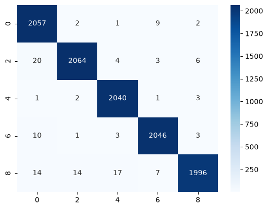

```python
import seaborn as sns
import matplotlib.pyplot as plt
sns.heatmap(cm, annot=True, fmt='d', cmap='Blues', xticklabels=[0, 2, 4, 6, 8], yticklabels=[0, 2, 4, 6, 8])
plt.show()
```

2046 6s in my test set were correctly classified

(60pts) Cluster the Iris species by writing your own Kmeans algorithm using THREE features (or modify the algorithm used in class). Show visualization of the data using a THREE dimensional scatter plot. Compare the clustering performance of your Kmeans algorithm to the sklearn implementation by making plots of the clusters from your method and Scikits implementation by showing the clusters from your methods and from Scikits method. What happens when you vary the number of clusters?

```python
from sklearn.datasets import load_iris
import pandas as pd
import seaborn as sns
import numpy as np
import matplotlib.pyplot as plt
```

```python
data = load_iris()
```

```python
df = pd.DataFrame()
df['sepal length'] = data['data'][:,0]
df['sepal width'] = data['data'][:,1]
df['petal length'] = data['data'][:,2]
```

```python
display(df)
```

|  | sepal length | sepal width | petal length |
| --- | --- | --- | --- |
| 0 | 5.1 | 3.5 | 1.4 |
| 1 | 4.9 | 3.0 | 1.4 |
| 2 | 4.7 | 3.2 | 1.3 |
| 3 | 4.6 | 3.1 | 1.5 |
| 4 | 5.0 | 3.6 | 1.4 |
| ... | ... | ... | ... |
| 145 | 6.7 | 3.0 | 5.2 |
| 146 | 6.3 | 2.5 | 5.0 |
| 147 | 6.5 | 3.0 | 5.2 |
| 148 | 6.2 | 3.4 | 5.4 |
| 149 | 5.9 | 3.0 | 5.1 |

150 rows × 3 columns

```python
X = df.to_numpy()
```

```python
df['target'] = data['target']
```

```python
print(data['target'])
```

```
[0 0 0 0 0 0 0 0 0 0 0 0 0 0 0 0 0 0 0 0 0 0 0 0 0 0 0 0 0 0 0 0 0 0 0 0 0
 0 0 0 0 0 0 0 0 0 0 0 0 0 1 1 1 1 1 1 1 1 1 1 1 1 1 1 1 1 1 1 1 1 1 1 1 1
 1 1 1 1 1 1 1 1 1 1 1 1 1 1 1 1 1 1 1 1 1 1 1 1 1 1 2 2 2 2 2 2 2 2 2 2 2
 2 2 2 2 2 2 2 2 2 2 2 2 2 2 2 2 2 2 2 2 2 2 2 2 2 2 2 2 2 2 2 2 2 2 2 2 2
 2 2]
```

```python
named_targets = []

for elm in df['target'].to_list():
    named_targets.append(data.target_names[elm])
print(named_targets)
```

```
[np.str_('setosa'), np.str_('setosa'), np.str_('setosa'), np.str_('setosa'), np.str_('setosa'), np.str_('setosa'), np.str_('setosa'), np.str_('setosa'), np.str_('setosa'), np.str_('setosa'), np.str_('setosa'), np.str_('setosa'), np.str_('setosa'), np.str_('setosa'), np.str_('setosa'), np.str_('setos…
```

```python
df['species_name'] = named_targets
print(df)
```

```
     sepal length  sepal width  petal length  target species_name
0             5.1          3.5           1.4       0       setosa
1             4.9          3.0           1.4       0       setosa
2             4.7          3.2           1.3       0       setosa
3             4.6          3.1           1.5       0       setosa
4             5.0          3.6           1.4       0       setosa
..            ...          ...           ...     ...          ...
145           6.7          3.0           5.2       2    virginica
146           6.3          2.5           5.0       2    virginica
147           6.5          3.0           5.2       2    virginica
148           6.2          3.4           5.4       2    virginica
149           5.9          3.0           5.1       2    virginica

[150 rows x 5 columns]
```

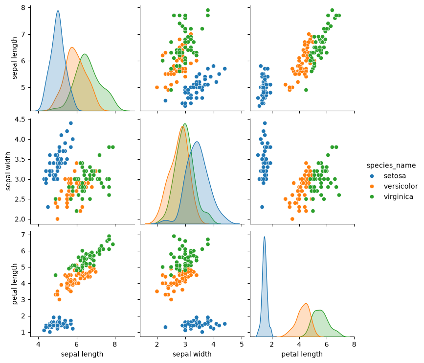

```python
sns.pairplot(df.drop(labels=['target'],axis=1), hue='species_name')
```

```python
from sklearn.model_selection import train_test_split
```

```python
X_train, X_test =train_test_split(
    X,
    test_size=0.30,
    train_size=0.70,
    random_state=123,
    shuffle=True)
```

```python
print('X_train shape :', X_train.shape)
print('X_test shape :', X_test.shape)
```

```
X_train shape : (105, 3)
X_test shape : (45, 3)
```

```python
y = df['target'].to_numpy()
```

```python
X_train, X_test, y_train, y_test, idx_train, idx_test=train_test_split(
    X,y, range(X.shape[0]),
    test_size=0.30,
    train_size=0.70,
    random_state=123,
    shuffle=True,
    stratify=y)
```

```python
print('X_train shape :', X_train.shape)
print('X_test shape :', X_test.shape)
print('y_train shape :', y_train.shape)
print('y_test shape :', y_test.shape)
```

```
X_train shape : (105, 3)
X_test shape : (45, 3)
y_train shape : (105,)
y_test shape : (45,)
```

```
['train', 'train', 'test', 'train', 'train', 'train', 'train', 'train', 'train', 'test', 'train', 'train', 'train', 'train', 'train', 'train', 'train', 'test', 'train', 'test', 'train', 'train', 'test', 'train', 'train', 'test', 'train', 'train', 'test', 'train', 'train', 'train', 'test', 'test', 't…
```

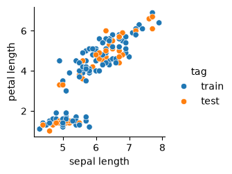

```python
tag = []

for _ in range(X.shape[0]):
    if _ in idx_train:
        tag.append('train')
    else:
        tag.append('test')

print(tag)
df['tag'] = tag

sns.pairplot(df.drop(labels=['target'],axis=1), x_vars=['sepal length'],
    y_vars=['petal length'], hue='tag')
```

```python
class KMeans:
    def __init__(self, k):
        self.k = k
        self.cluster_labels = None
    def fit(self, X):
        self.centroids = X[np.random.choice(X.shape[0], self.k, replace=False), :]
        self.cluster_labels = np.arange(self.k)
        while True:
            distances = np.array([np.linalg.norm(X - centroid, axis=1) for centroid in self.centroids])
            self.clusters = np.argmin(distances, axis=0)
            new_centroids = np.array([X[self.clusters == i, :].mean(axis=0) for i in range(self.k)])
            # check convergence
            if np.array_equal(new_centroids, self.centroids):
                break
            else:
                self.centroids = new_centroids

    def predict(self, X):
        distances = np.array([np.linalg.norm(X - centroid, axis=1) for centroid in self.centroids])
        return self.cluster_labels[np.argmin(distances, axis=0)]
```

```python
model = KMeans(k=3)
model.fit(X_train)
kmeans_labels = model.predict(X_test)
cluster_coords = model.centroids
print('predicted_labels:', kmeans_labels)
print('cluster centroids:', cluster_coords)
```

```
predicted_labels: [0 2 0 2 2 1 1 0 1 1 2 1 2 1 0 1 0 0 1 1 1 1 1 0 1 0 2 1 2 2 2 2 0 0 0 0 0
 2 2 1 2 0 0 2 0]
cluster centroids: [[5.82619048 2.72142857 4.35238095]
 [5.04285714 3.43428571 1.48857143]
 [6.77857143 3.02857143 5.62142857]]
```

```python
y_train
```

```
array([1, 0, 1, 2, 0, 2, 0, 2, 1, 0, 2, 2, 2, 0, 0, 0, 0, 0, 0, 2, 2, 0,
       2, 1, 0, 1, 0, 2, 2, 1, 2, 2, 2, 1, 1, 0, 1, 1, 1, 1, 1, 2, 1, 0,
       0, 2, 1, 0, 1, 2, 0, 2, 0, 0, 1, 1, 1, 2, 1, 2, 2, 0, 0, 2, 2, 2,
       0, 2, 0, 1, 1, 2, 2, 0, 0, 0, 1, 1, 2, 1, 2, 2, 1, 1, 1, 1, 0, 0,
       1, 1, 2, 2, 0, 0, 1, 2, 1, 2, 1, 0, 1, 0, 0, 0, 2])
```

```python
df['kmeans_labels'] = model.predict(X)
```

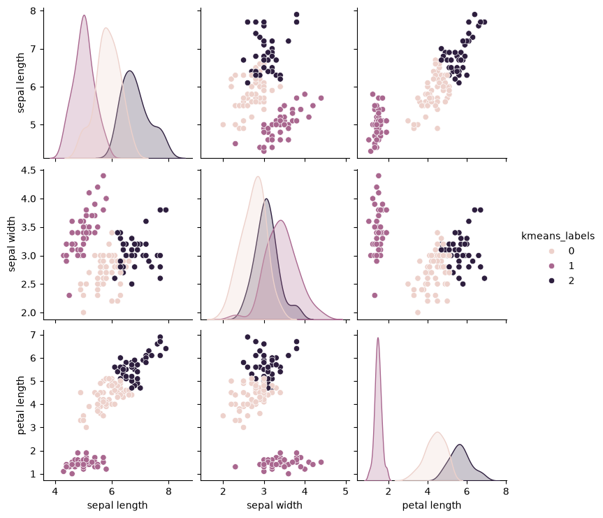

```python
sns.pairplot(df.drop(labels=['target'],axis=1), hue='kmeans_labels')
```

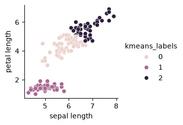

```python
sns.pairplot(df.drop(labels=['target'],axis=1), x_vars=['sepal length'],
    y_vars=['petal length'], hue='kmeans_labels')
```

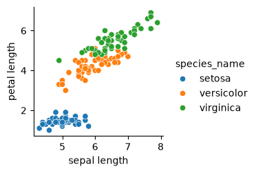

```python
sns.pairplot(df.drop(labels=['target'],axis=1), x_vars=['sepal length'],
    y_vars=['petal length'], hue='species_name')
```

```python
df.columns
```

```
Index(['sepal length', 'sepal width', 'petal length', 'target', 'species_name',
       'tag', 'kmeans_labels'],
      dtype='str')
```

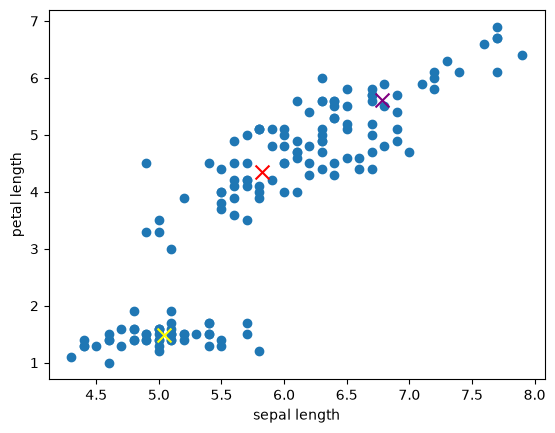

```python
plt.scatter(df['sepal length'].to_list(), df['petal length'].to_list())
plt.scatter(cluster_coords[0][0], cluster_coords[0][2], color='red', marker='x', s=100)
plt.scatter(cluster_coords[1][0], cluster_coords[1][2], color='yellow', marker='x', s=100)
plt.scatter(cluster_coords[2][0], cluster_coords[2][2], color='purple', marker='x', s=100)
plt.xlabel('sepal length')
plt.ylabel('petal length')
```

Now to test Sklearn

```python
from sklearn.cluster import KMeans
skmodel = KMeans(
    n_clusters=3,
    init='k-means++',
    n_init='auto',
    max_iter=300,
    tol=0.0001,
    verbose=0,
    random_state=None,
    copy_x=True,
    algorithm='lloyd',
)

skmodel.fit(X_train)
```

```
KMeans(n_clusters=3)
```

```python
skmodel.labels_ # training labels
```

```
array([0, 1, 0, 2, 1, 0, 1, 2, 0, 1, 2, 2, 2, 1, 1, 1, 1, 1, 1, 0, 2, 1,
       2, 0, 1, 0, 1, 0, 2, 0, 2, 2, 2, 0, 0, 1, 0, 0, 0, 0, 0, 2, 2, 1,
       1, 2, 0, 1, 2, 2, 1, 2, 1, 1, 0, 0, 0, 2, 0, 2, 0, 1, 1, 2, 2, 0,
       1, 0, 1, 0, 0, 2, 2, 1, 1, 1, 0, 0, 2, 0, 0, 2, 0, 0, 0, 0, 1, 1,
       0, 0, 2, 0, 1, 1, 0, 0, 0, 2, 0, 1, 0, 1, 1, 1, 2], dtype=int32)
```

```python
skmodel.predict(X_test)
```

```
array([0, 2, 0, 2, 2, 1, 1, 0, 1, 1, 2, 1, 2, 1, 0, 1, 0, 0, 1, 1, 1, 1,
       1, 0, 1, 0, 2, 1, 2, 2, 2, 2, 0, 0, 0, 0, 0, 2, 2, 1, 2, 0, 0, 2,
       0], dtype=int32)
```

```python
skmodel_labels = skmodel.predict(X)
```

```python
df['skmodel_labels'] = skmodel_labels
```

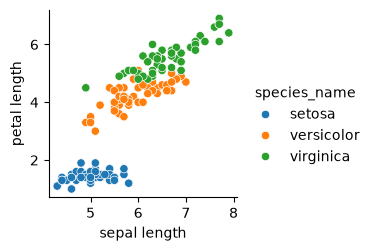

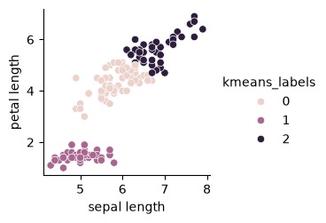

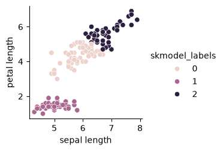

```python
sns.pairplot(df.drop(labels=['target'],axis=1), x_vars=['sepal length'],
    y_vars=['petal length'], hue='species_name')
# too many plots so let's trim them down

sns.pairplot(df.drop(labels=['target'],axis=1), x_vars=['sepal length'],
    y_vars=['petal length'], hue='kmeans_labels')
sns.pairplot(df.drop(labels=['target'],axis=1), x_vars=['sepal length'],
    y_vars=['petal length'], hue='skmodel_labels')
```

```python
print(df)
```

```
     sepal length  sepal width  petal length  target species_name    tag  \
0             5.1          3.5           1.4       0       setosa  train
1             4.9          3.0           1.4       0       setosa  train
2             4.7          3.2           1.3       0       setosa   test
3             4.6          3.1           1.5       0       setosa  train
4             5.0          3.6           1.4       0       setosa  train
..            ...          ...           ...     ...          ...    ...
145           6.7          3.0           5.2       2    virginica  train
146           6.3          2.5           5.0       2    virginica   test
147           6.5          3.0           5.2       2    virginica  train
148           6.2          3.4           5.4       2    virginica  train
149           5.9          3.0           5.1       2    virginica  train

     kmeans_labels  skmodel_labels
0                1               1
1                1               1
2                1               1
3                1               1
4                1               1
..             ...             ...
145              2               2
146              0               0
147              2               2
148              2               2
149              0               0

[150 rows x 8 columns]
```

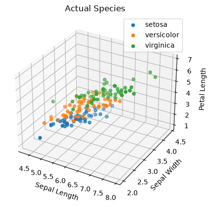

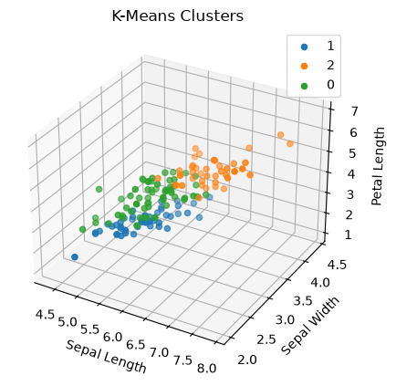

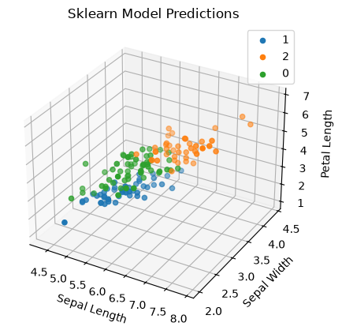

```python
fig = plt.figure()
ax = fig.add_subplot(111, projection='3d')

for species in df['species_name'].unique():
    data = df[df['species_name'] == species]

    ax.scatter(
        data['sepal length'],
        data['sepal width'],
        data['petal length'],
        label=species
    )

ax.set_xlabel('Sepal Length')
ax.set_ylabel('Sepal Width')
ax.set_zlabel('Petal Length')

ax.legend()
plt.title('Actual Species')
plt.show()

fig = plt.figure()
ax = fig.add_subplot(111, projection='3d')

for species in df['kmeans_labels'].unique():
    data = df[df['kmeans_labels'] == species]

    ax.scatter(
        data['sepal length'],
        data['sepal width'],
        data['petal length'],
        label=species
    )

ax.set_xlabel('Sepal Length')
ax.set_ylabel('Sepal Width')
ax.set_zlabel('Petal Length')

ax.legend()
plt.title('K-Means Clusters')
plt.show()

fig = plt.figure()
ax = fig.add_subplot(111, projection='3d')

for species in df['skmodel_labels'].unique():
    data = df[df['skmodel_labels'] == species]

    ax.scatter(
        data['sepal length'],
        data['sepal width'],
        data['petal length'],
        label=species
    )

ax.set_xlabel('Sepal Length')
ax.set_ylabel('Sepal Width')
ax.set_zlabel('Petal Length')

ax.legend()
plt.title('Sklearn Model Predictions')
plt.show()
```